# Exploring County Health with SHAP Values

Understanding What Drives Poor Health Outcomes Across U.S. Counties

Author

DS 400: Bayesian Statistics

Published

October 14, 2025

## 🏥 Introduction: What Makes Communities Healthy?

What factors contribute most to poor health outcomes in U.S. counties? Is it education? Income? Access to healthcare? Environmental quality?

In this analysis, we’ll use **County Health Rankings** data combined with **Random Forests** and **SHAP (SHapley Additive exPlanations)** values to uncover the key drivers of health outcomes across America.

**Analysis Goals**

- Build a predictive model for poor health outcomes
- Identify the most important features driving predictions
- Understand how individual features affect health outcomes
- Explore specific county predictions with SHAP values

## 📦 Load Required Packages

```r
library(tidyverse)
library(here)
library(readxl)
library(janitor)
library(naniar)
library(randomForest)
library(treeshap)
```

**What are SHAP Values?**

SHAP (SHapley Additive exPlanations) values explain the output of machine learning models by assigning each feature an importance value for a particular prediction. They’re based on game theory and provide consistent, interpretable explanations!

## 📊 Load and Prepare the Data

### Import County Health Rankings Data

```r
chr_data <- read_excel(here("data", "2025_County_Health_Rankings_Data.xlsx"), sheet = 2, skip = 1)
chr_data <- chr_data %>%
  clean_names()
```

**Challenge Problem #1**

Create a map showing `percent_fair_or_poor_health` by county. You’ll need to:

- Use an AI assistant
  - run glimpse(chr_data) in the console
  - copy and paste the output into an AI
  - prompt it to write simple and effective R code to make a choropleth map of `percent_fair_or_poor_health`by county

Give it a try!

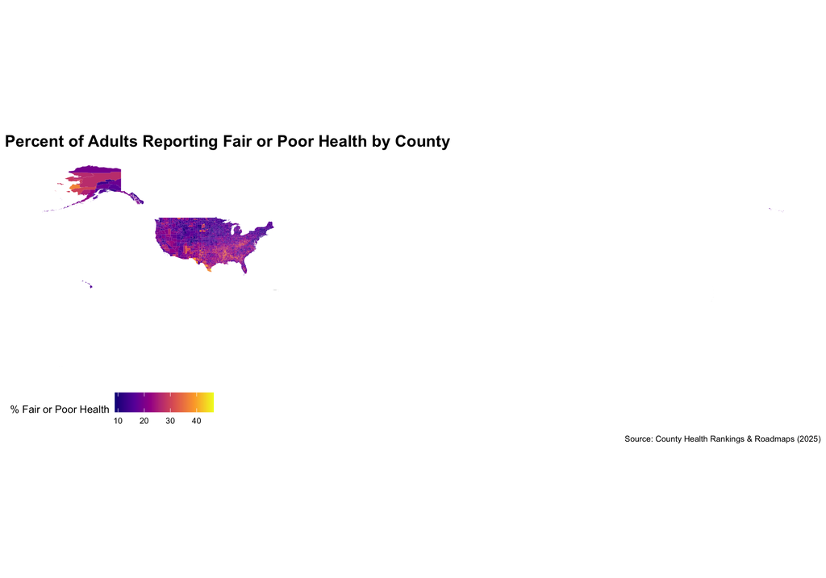

```r
library(sf)
library(tigris)
library(ggthemes)

# Download U.S. county shapefile (simple features)
counties <- tigris::counties(cb = TRUE, year = 2023) %>%
  st_as_sf() %>%
  mutate(fips = paste0(STATEFP, COUNTYFP))
# Prepare data for join
chr_map <- chr_data %>%
  select(fips, percent_fair_or_poor_health) %>%
  mutate(fips = str_pad(fips, width = 5, pad = "0"))  # ensure 5-digit FIPS codes

# Join health data with county geometry
map_data <- counties %>%
  left_join(chr_map, by = "fips")

# Plot the choropleth
ggplot(map_data) +
  geom_sf(aes(fill = percent_fair_or_poor_health), color = NA) +
  scale_fill_viridis_c(option = "plasma", na.value = "grey90",
                       name = "% Fair or Poor Health") +
  labs(
    title = "Percent of Adults Reporting Fair or Poor Health by County",
    caption = "Source: County Health Rankings & Roadmaps (2025)"
  ) +
  theme_map() +
  theme(legend.position = "bottom",
        plot.title = element_text(size = 14, face = "bold"))
```

### Select Key Health Determinants

We’re focusing on social, economic, and environmental factors that might influence health outcomes:

```r
chr_data <- chr_data %>%
  select(food_environment_index,
         percent_uninsured,
         percent_severe_housing_problems,
         percent_households_with_broadband_access,
         average_daily_pm2_5,
         percent_unemployed,
         income_ratio,
         percent_children_in_poverty,
         social_association_rate,
         preventable_hospitalization_rate,
         percent_completed_high_school,
         percent_some_college,
         percent_fair_or_poor_health)
```

**📋 Variable Definitions**

- **Food Environment Index**: Measures access to healthy foods
- **Percent Uninsured**: Population without health insurance
- **Percent Severe Housing Problems**: Housing quality and affordability issues
- **Broadband Access**: Households with internet access
- **PM2.5**: Air pollution (particulate matter)
- **Income Ratio**: Ratio of household income at 80th to 20th percentile
- **Social Association Rate**: Membership in civic organizations
- **Preventable Hospitalization Rate**: Hospital visits that could have been prevented
- **Education Variables**: High school and college completion rates
- **Percent Fair or Poor Health**: Our outcome variable (self-reported health status)

## 🔍 Exploratory Data Analysis

### Distribution of Our Outcome Variable

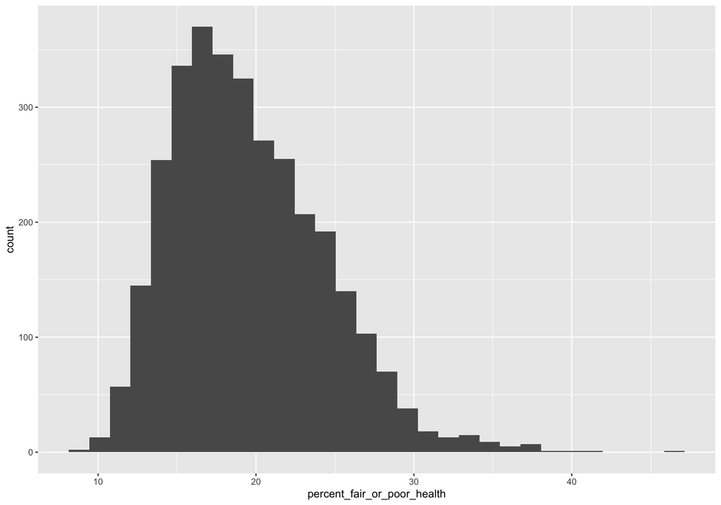

Distribution of self-reported poor health across U.S. counties

```r
ggplot(chr_data, aes(x = percent_fair_or_poor_health)) +
  geom_histogram()
```

## 🕵️ Missing Data Investigation

Before building our model, let’s check for missing values:

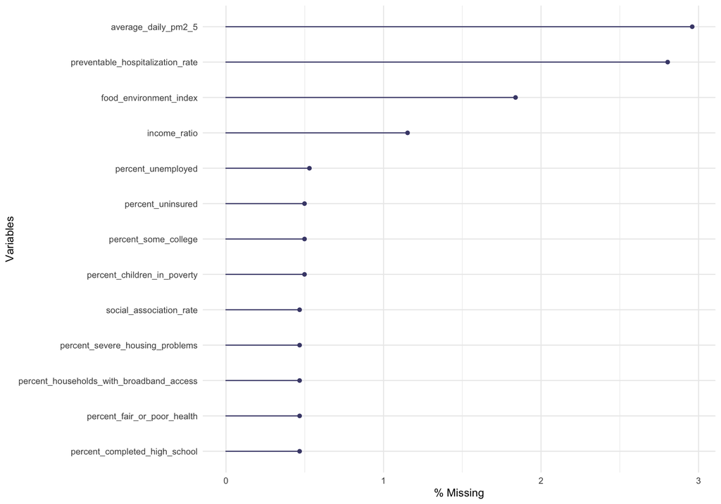

Missing data patterns in our health dataset

```r
naniar::gg_miss_var(chr_data, show_pct = TRUE)
```

### Handle Missing Data

```r
chr_data <- chr_data %>%
  drop_na()
```

**Data Cleaning Note**

We’re using complete case analysis here (dropping rows with any missing values). In practice, you might want to explore more sophisticated imputation methods, especially if missingness is substantial or not random.

## 🌲 Build the Random Forest Model

Let’s train a Random Forest to predict the percentage of people reporting fair or poor health:

```r
rf = randomForest(percent_fair_or_poor_health ~ ., data = chr_data, ntree = 500)
rf
```

```
Call:
 randomForest(formula = percent_fair_or_poor_health ~ ., data = chr_data,      ntree = 500)
               Type of random forest: regression
                     Number of trees: 500
No. of variables tried at each split: 4

          Mean of squared residuals: 3.675384
                    % Var explained: 83.24
```

**Model Performance**

Look at the `% Var explained` metric. This tells us how much of the variance in health outcomes our model can explain using these social, economic, and environmental factors. Also look a the `Mean of squared residuals -`The average of the squared differences between the actual health outcomes and the model’s predictions. Lower values indicate better predictive accuracy.

## 🔬 SHAP Analysis: Understanding Feature Importance

### Prepare for SHAP Calculation

```r
unified <- unify(rf, chr_data)
treeshap1 <- treeshap(unified,  chr_data[1:200, ], verbose = 0)
```

## 📊 Feature Importance

Which factors matter most for predicting poor health outcomes?

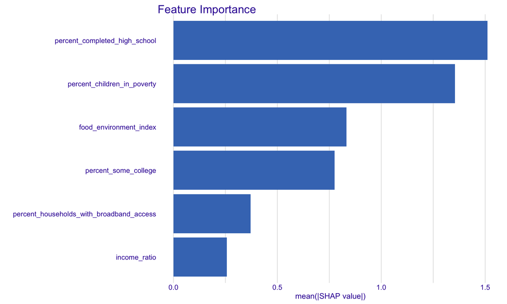

Top 6 most important features for predicting poor health outcomes

```r
plot_feature_importance(treeshap1, max_vars = 6)
```

**Key Insight**

The features at the top have the biggest impact on predictions across all counties. These are the “leverage points” where interventions might have the greatest effect on community health!

## 📈 Feature Dependence: Deep Dive

### Education’s Impact on Health

How does high school completion affect health outcomes?

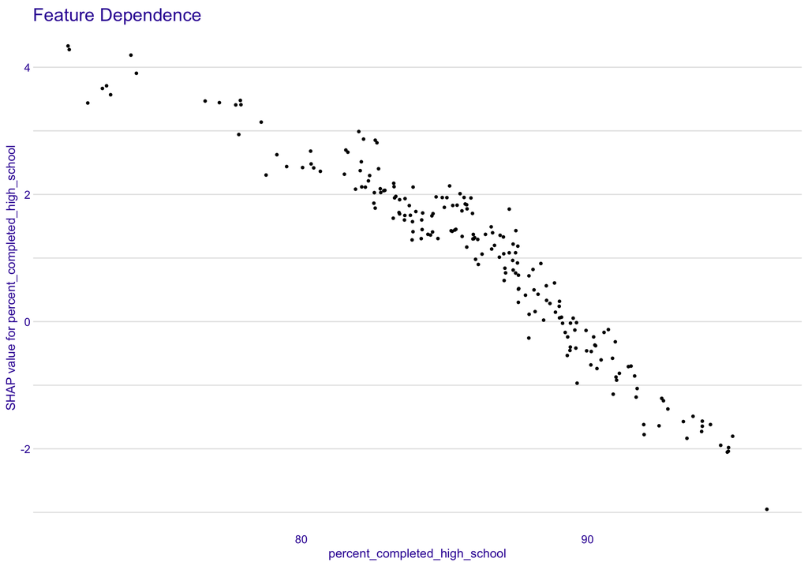

Relationship between high school completion and SHAP values for health outcomes

```r
plot_feature_dependence(treeshap1, "percent_completed_high_school")
```

**Interpreting This Plot**

- **X-axis**: The actual values of the feature (% high school completion)
- **Y-axis**: The SHAP value (how much this feature pushes predictions up or down)
- **Pattern**: Look for trends - does higher education consistently lead to better health predictions?

**Challenge Problem #2**

Create feature dependence plots for the next 4 most important variables from the feature importance plot above.

**Hint**: Use the same `plot_feature_dependence()` function but change the variable name.

```r
# Template:
# plot_feature_dependence(treeshap1, "your_variable_name_here")
```

What patterns do you notice? Are the relationships linear or non-linear?

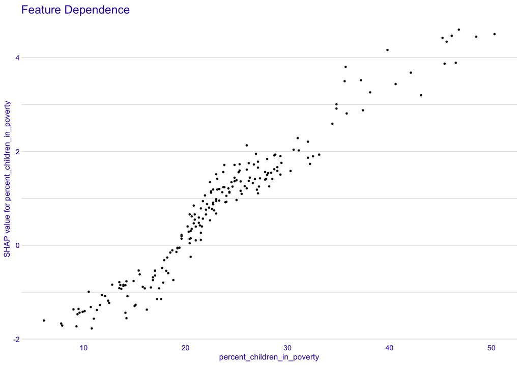

```r
plot_feature_dependence(treeshap1, "percent_children_in_poverty")
```

## 🎯 Individual County Analysis

Let’s examine what drives the prediction for a specific county:

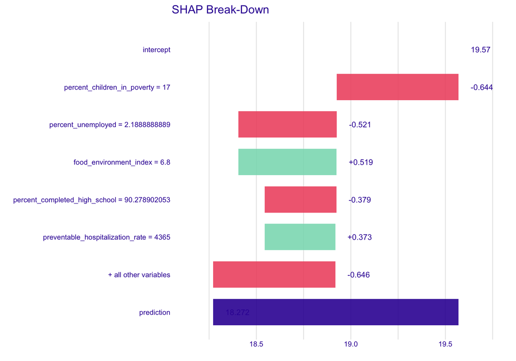

SHAP contribution plot for observation 2: How each feature affects this county’s prediction

```r
plot_contribution(treeshap1, obs = 2)
```

**Reading the Contribution Plot**

This shows you exactly which factors make this particular county’s health outcomes better or worse than the baseline!

## 🎓 Reflection Questions

**Think About It**

1. **Policy Implications**: Based on the feature importance, which 2-3 areas should local governments prioritize for improving community health?
2. **Causality vs Correlation**: Does this analysis prove that these features *cause* poor health outcomes? Why or why not?
3. **Equity Considerations**: Do you notice any patterns that might indicate health disparities related to socioeconomic factors?
4. **Model Limitations**: What important factors might be missing from this analysis? What would you add if you could?
5. **Intervention Planning**: If you were a county health director, how would you use these SHAP values to design interventions?

## 💡 Key Takeaways

**What We Learned**

1. **Random Forests** can effectively model complex health outcomes using multiple predictors
2. **SHAP values** provide interpretable insights into both:
   - Global feature importance (what matters overall)
   - Local explanations (what matters for specific counties)
3. **Health is multifaceted** - education, economics, environment, and social factors all play important roles
4. **Machine learning + interpretability** tools like SHAP help us move from black-box predictions to actionable insights

## 📚 Additional Resources

- [SHAP Documentation](https://shap.readthedocs.io/)
- [County Health Rankings Methodology](https://www.countyhealthrankings.org/)
- [treeshap R Package](https://github.com/ModelOriented/treeshap)
- Random Forests in R: Breiman & Cutler’s [Random Forest Page](https://www.stat.berkeley.edu/~breiman/RandomForests/)

## 🔬 Your Turn: Extend the Analysis

**Extension Ideas**

1. **Try different sample sizes** for SHAP calculation (we used 200 counties)
2. **Compare multiple observations** - pick 3-5 diverse counties and compare their contribution plots
3. **Experiment with model parameters** - try different `ntree` values in the Random Forest
4. **Temporal analysis** - if you have data from multiple years, track how feature importance changes over time
5. **Subgroup analysis** - split by region or urbanicity and build separate models

*This analysis demonstrates the power of combining machine learning with interpretable AI techniques to understand complex public health outcomes. The insights generated can inform evidence-based policy decisions and targeted interventions!*